# 6-ый этап индивидуального проекта

Операционные системы

Верниковская Е. А., НПИбд-01-23

Российский университет дружбы народов, Москва, Россия

23 мая 2024

# Вводная часть

## Цель работы

Размещение двуязычного сайта на Github.

## Задание

1. Сделать поддержку английского и русского языков.
2. Разместить элементы сайта на обоих языках.
3. Разместить контент на обоих языках.
4. Сделать пост по прошедшей неделе.
5. Добавить пост на тему по выбору (на двух языках).

# Выполнение 6-ого этапа индивидуального проекта

## Поддержка английского и русского языка на сайте

Заходим в каталог ~/work/blog. Далее запускаем исполняемый файл hugo, с помощью команды *~/bin/hugo server* и переходим на наш локальный сайт (рис. 1)

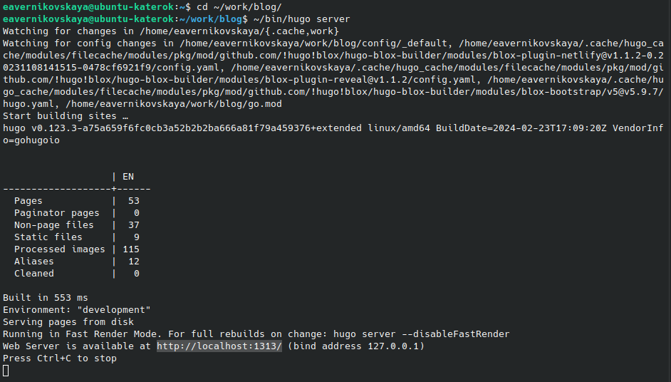

Запуск исполняемого файла

## Поддержка английского и русского языка на сайте

Далее скачиваем из репозитория hugo два файла *en.yaml* и *ru.yaml* (рис. 2), (рис. 3)

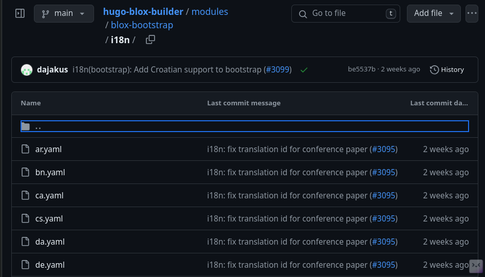

Репозиторий hugo

## Поддержка английского и русского языка на сайте

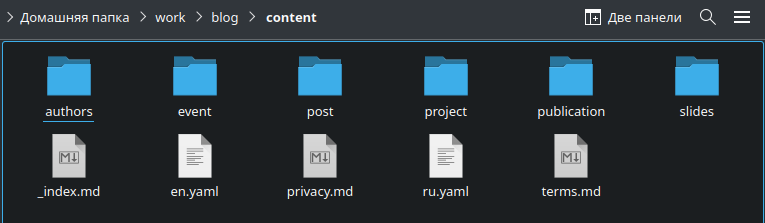

Скаченные файлы

## Поддержка английского и русского языка на сайте

В каталоге ~/work/blog/content создаём две папки с названиями *en* и *ru*. Там будут хранится файлы на английском и русском языках (рис. 4)

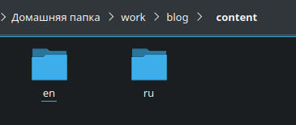

Папки en и ru

## Поддержка английского и русского языка на сайте

Перемещаем все файлы, которые были до этого в каталоге ~/work/blog/content в каталог ~/work/blog/content/ru. Также переносим туда файл ru.yaml. Те же файлы копируем в каталог ~/work/blog/content/en. Только вместо файла ru.yaml перемещаем туда файл en.yaml (рис. 5), (рис. 6)

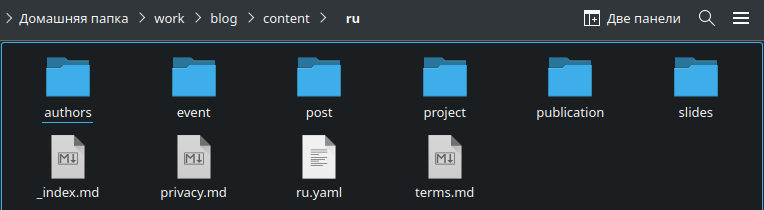

Каталог ~/work/blog/content/ru

## Поддержка английского и русского языка на сайте

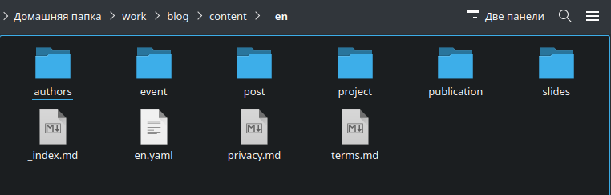

Каталог ~/work/blog/content/en

## Поддержка английского и русского языка на сайте

Далее в каталоге ~/work/blog/config/_default редактируем конфигурационный файл languages.yaml (рис. 7), (рис. 8)

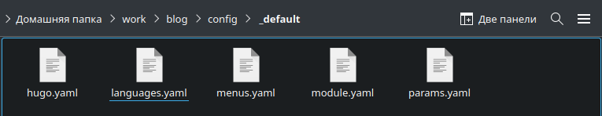

Каталог ~/work/blog/config/_default

## Поддержка английского и русского языка на сайте

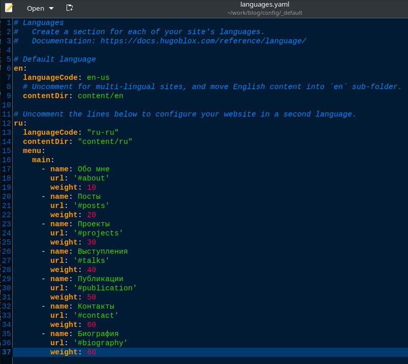

Файл languages.yaml

## Поддержка английского и русского языка на сайте

Далее редактируем конфигурационный файл hugo.yaml (рис. 10)

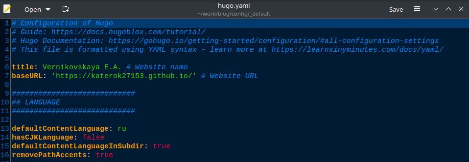

Файл hugo.yaml

## Поддержка английского и русского языка на сайте

В каталоге ~/work/blog/content/en все файлы пишем на английском языке

## Размещение постов на сайте на двух языках

Переходим в каталог ~/work/blog/ru/content/post и создаём две папки (я назвала их *post_9* и *post_10*), где будут хранится материалы постов (рис. 11), (рис. 12), (рис. 13)

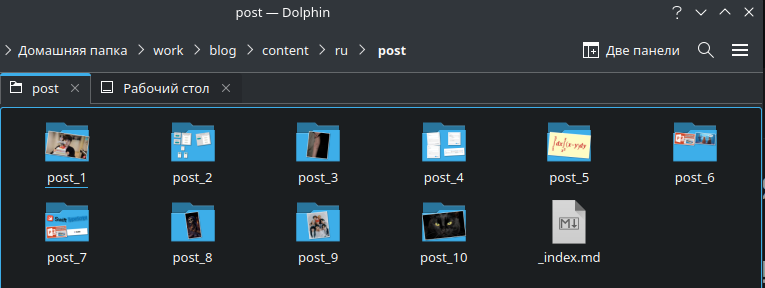

Папки с материалама постов на русском

## Размещение постов на сайте на двух языках

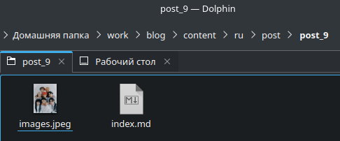

Материалы для поста о прошедшей неделе

## Размещение постов на сайте на двух языках

[figure not shown]

Материалы для поста по выбранной теме

## Размещение постов на сайте на двух языках

Редактируем в папке post_9 файл index.md. Пишем там пост о нашей прошедшей неделе, по желанию вставляем картинки (рис. 14)

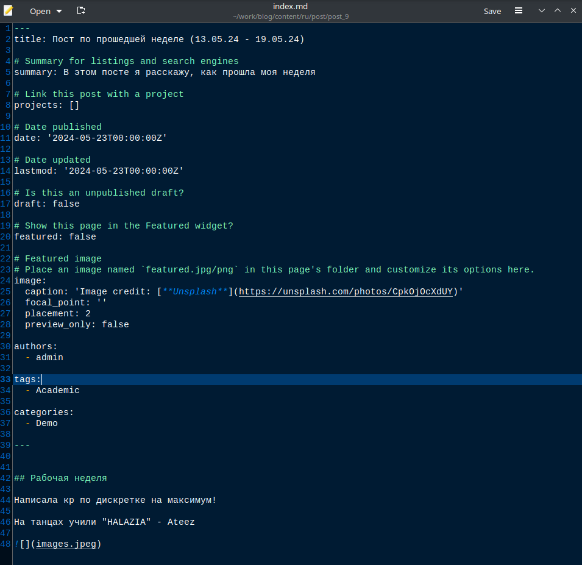

Файл поста по прошедшей неделе

## Размещение постов на сайте на двух языках

Далее редактируем другой файл index.md в папке post_10, где будет пост по выбранной теме (рис. 15)

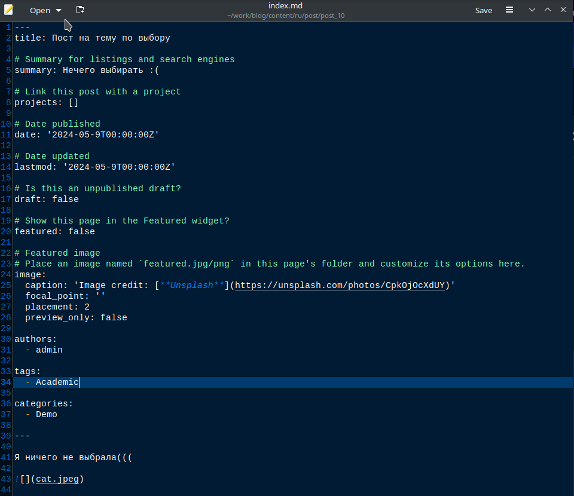

Файл поста по выборанной теме

## Размещение постов на сайте на двух языках

Тоже самое делаем в каталоге ~/work/blog/en/content/post. Создаём две папки и редактируем файлы index.md. Только пишем весь материал уже на английском (рис. 16)

[figure not shown]

Папки с материалама постов на английском

## Сборка сайта

Собираем наш сайт выполнив в каталоге ~/work/blog команду *~/bin/hugo* (рис. 17)

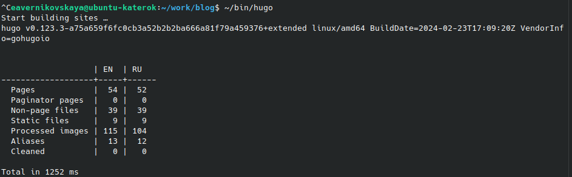

Сборка сайта

## Сборка сайта

Далее сохраняем изменения и отправляем их на git (рис. 18), (рис. 19)

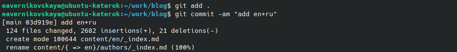

Сохранение и коммит изменений (1)

## Сборка сайта

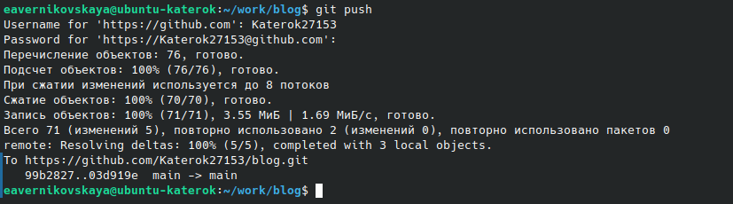

Отправка изменений на git (1)

## Сборка сайта

Далее переходим в каталог ~/work/blog/public и также сохраняем изменения и выкладываем их на git (рис. 20), (рис. 21)

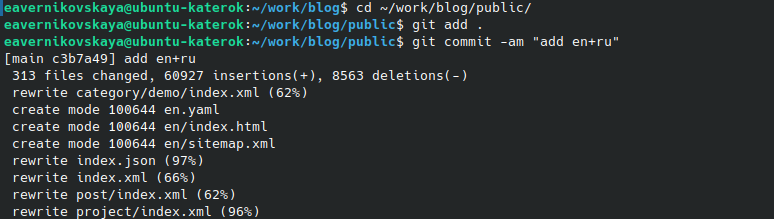

Сохранение и коммит изменений(2)

## Сборка сайта

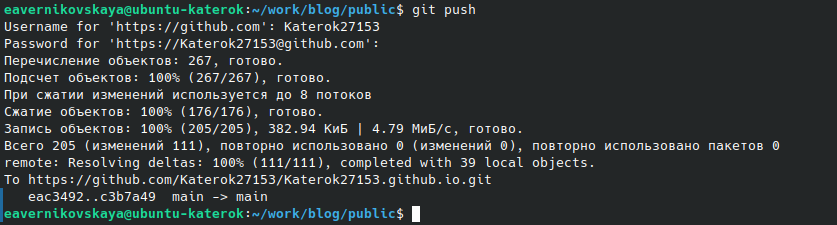

Отправка изменений на git (2)

## Сборка сайта

[figure not shown]

Информация о владельце сайта на русском

## Сборка сайта

[figure not shown]

Информация о владельце сайта на английском

## Сборка сайта

[figure not shown]

Посты на русском

## Сборка сайта

[figure not shown]

Посты на английском

## Сборка сайта

[figure not shown]

Проекты на русском

## Сборка сайта

[figure not shown]

Проекты на английском

## Сборка сайта

[figure not shown]

Хобби и технические навыки на русском

## Сборка сайта

[figure not shown]

Хобби и технические навыки на английском

## Сборка сайта

[figure not shown]

Информация об опыте на русском

## Сборка сайта

[figure not shown]

Информация об опыте на английском

# Подведение итогов

## Выводы

В ходе выполнения 6-ого этапа индивидуального проекта мы сделали поддрежку двух языков (английского и русского), а также научились размещать на сайте материалы на двух языках

## Список литературы

1. Мой сайт [Электронный ресурс] URL: https://katerok27153.github.io/
2. Этапы реализации проекта [Электронный ресурс] URL: https://esystem.rudn.ru/mod/page/view.php?id=1098920
3. Официальная библиотека иконок [Электронный ресурс] URL: https://fontawesome.ru/all-icons/